# Solutions to Exercise Sheet 1

If our data set is stored as a Tibble, then categorical variables are simply columns containing characters. If we wish to use the catagorical variables in an alalysis then we need to convert them to a type of object called a factor. To convert the categorical variables (currently stored as characters) to factors

```r
cholesterol$Gender <- as_factor(cholesterol$Gender)
cholesterol$Smoking <- as_factor(cholesterol$Smoking)
cholesterol$Smoking <- as_factor(cholesterol$Smoking)
```

Next we plot histograms for all 4 variables.

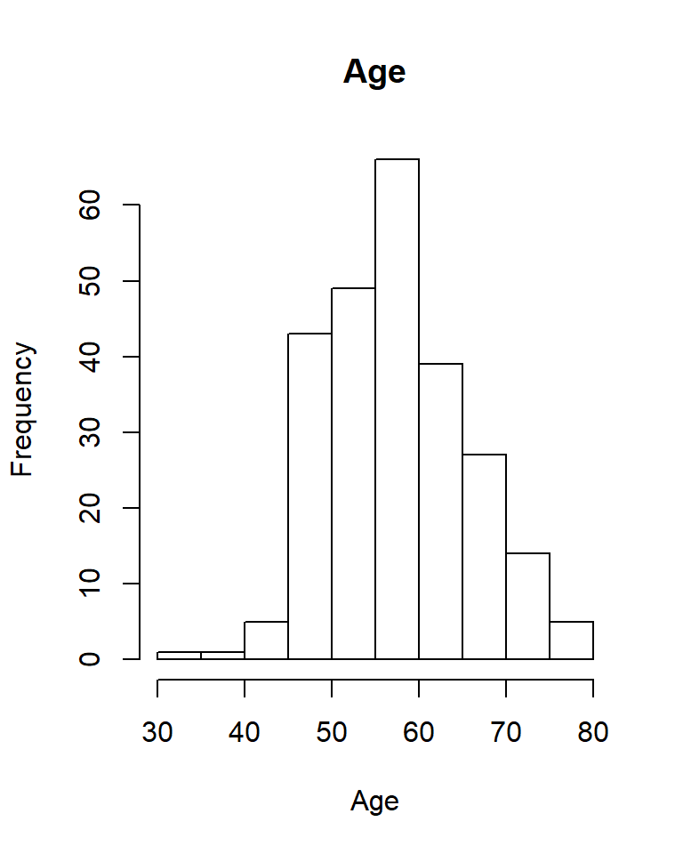

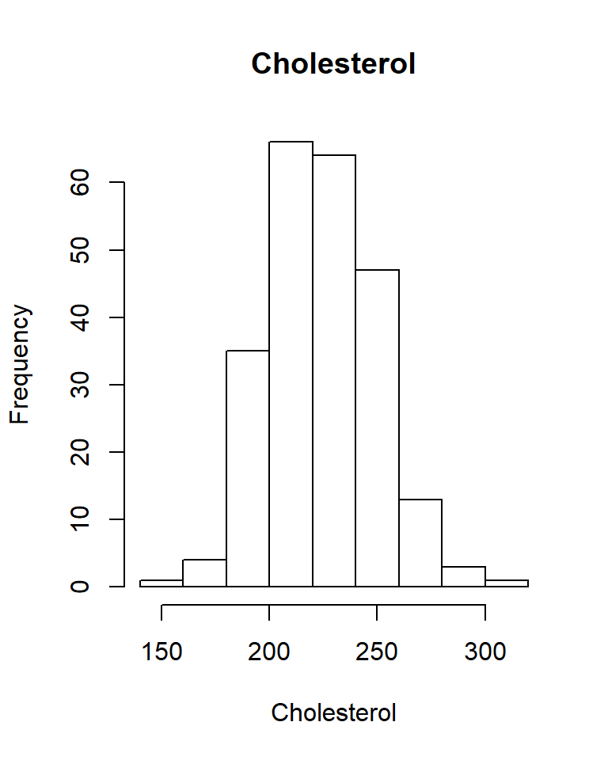

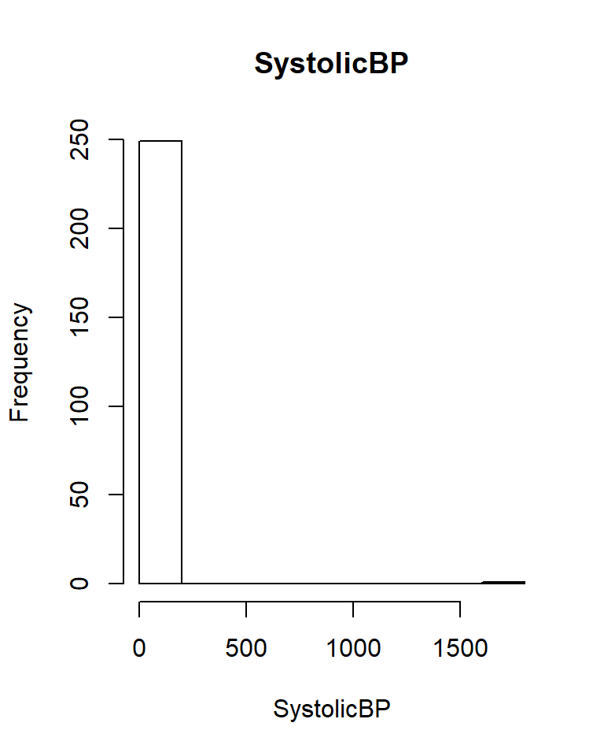

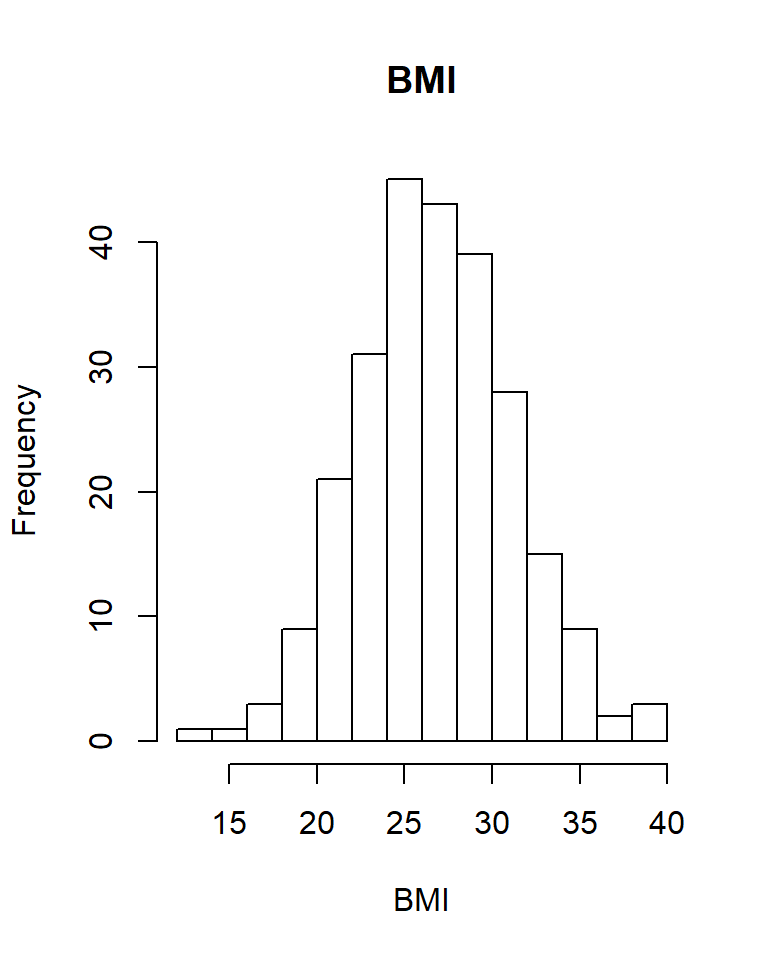

```r
for(i in c(1,3,4,5)) hist(cholesterol[[i]], xlab = names(cholesterol[i]), main = names(cholesterol[i]))
```

The distribution of all the variables apart from SystolicBPlook normal.  
SystolicBP looks skewed a transformation may help but the number of large values seems small on the histogram so lets investigate further using boxplots.

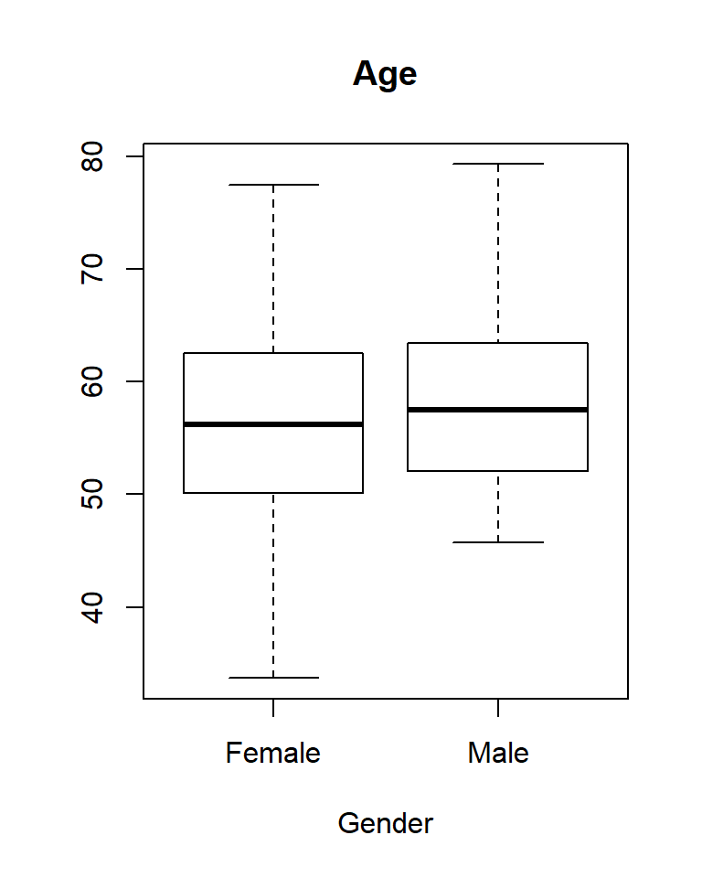

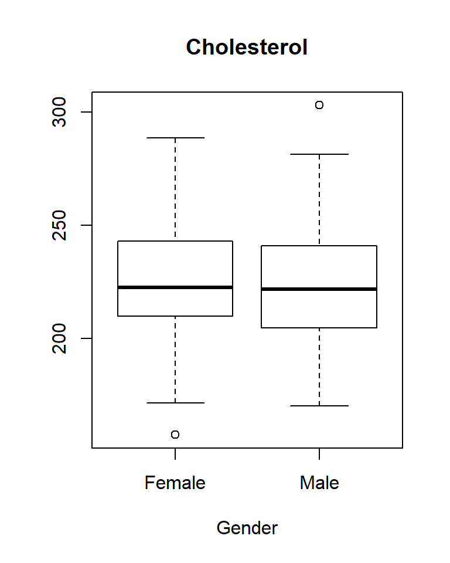

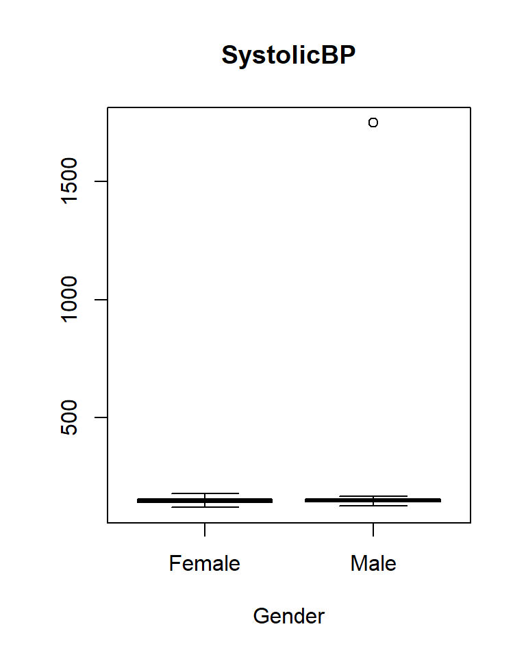

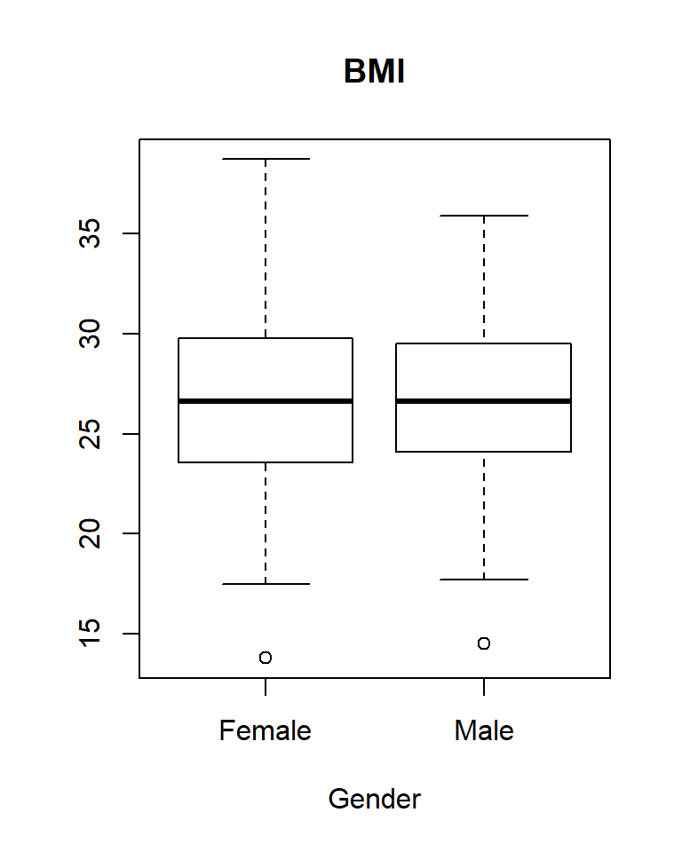

```r
for(i in c(1,3,4,5)) boxplot(cholesterol[[i]]~cholesterol$Gender, xlab = "Gender", main = names(cholesterol[i]))
```

The box plots above show that distribution of the continuous variables are similar for males and females, etc. There appear to be some potential outliers, one particular value for SystolicBP looks very high - it has a value of 1750 - this is not a valid measurement for blood pressure so it could be replaced with an NA. We can replace the value of 1750 with an NA and recheck the distributions

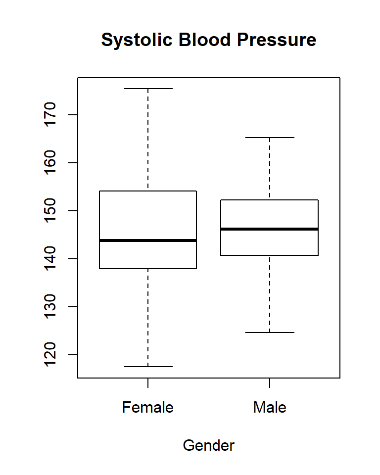

```r
cholesterol<- cholesterol %>% mutate(SystolicBP = (replace(SystolicBP, SystolicBP==1750, NA)))
boxplot(cholesterol$SystolicBP~cholesterol$Gender, xlab = "Gender", main = "Systolic Blood Pressure")
```

Note that the skew has gone from SystolicBP

The scatterplots below don’t show any relationships between the continuous variables.

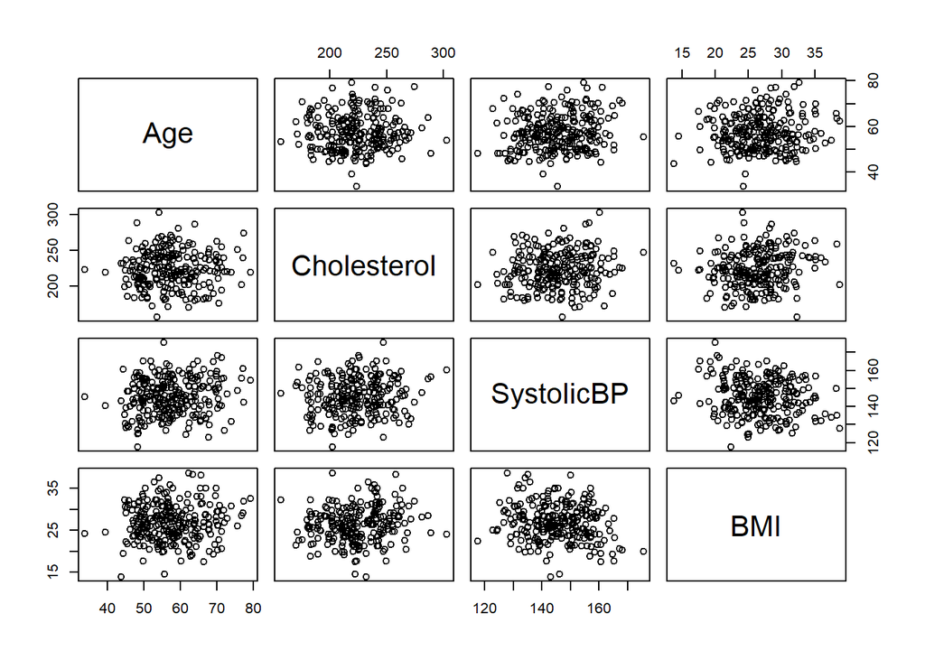

```r
pairs(cholesterol[,c(1,3,4,5)])
```

The aggr function gives us an overview of the missing data.

```r
a <- aggr(cholesterol)
```

[figure not shown]

There are 16 missing data in Cholesterol and 1 in SystolicBP To check for missing data patterns we can use the histMiss() and marginplot() functions for the continuous variables and the barMiss() function for the categorical variables. First need to convert the cholesterol tibble to a dataframe to use some of the functions in the VIM package.

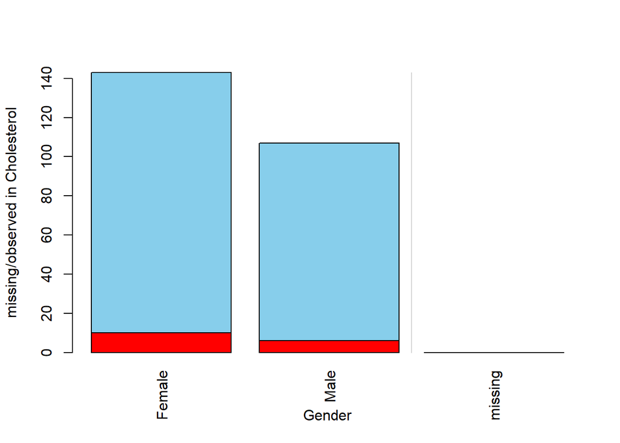

```r
cholesterol<-as.data.frame(cholesterol)

barMiss(cholesterol[,c("Gender", "Cholesterol")])
```

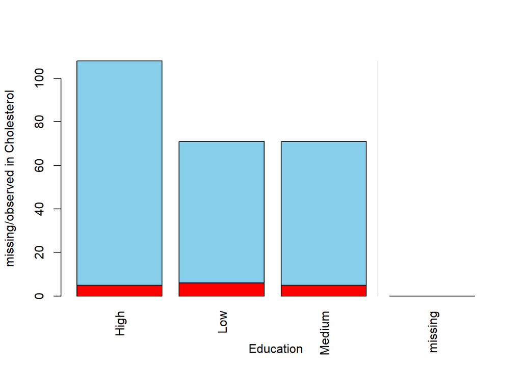

```r
barMiss(cholesterol[,c("Education", "Cholesterol")])
```

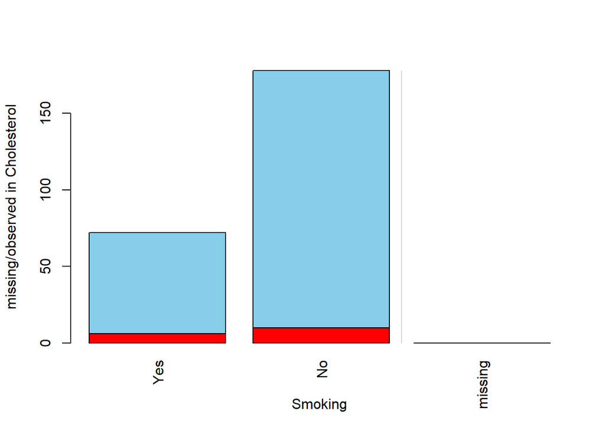

```r
barMiss(cholesterol[c("Smoking","Cholesterol")])
```

There appear to be more missing cholesterol values for female patients

```r
by(cholesterol$Cholesterol,cholesterol$Gender, summary)
```

```
## cholesterol$Gender: Female
##    Min. 1st Qu.  Median    Mean 3rd Qu.    Max.    NA's
##   157.5   209.9   222.5   224.3   242.9   288.7      10
## --------------------------------------------------------
## cholesterol$Gender: Male
##    Min. 1st Qu.  Median    Mean 3rd Qu.    Max.    NA's
##   170.3   204.6   221.9   223.0   240.9   303.0       6
```

Out of a total of 250 observations (143 female and 107 male) there are 10 missing values for females and 6 for males. We can test to see whether there is a significant difference using prop.test. If you have not used this test before, be sure to look up the help for this function to find out how it works.

```r
prop.test(c(10,6), c(143,107))
```

```
##
##  2-sample test for equality of proportions with continuity
##  correction
##
## data:  c(10, 6) out of c(143, 107)
## X-squared = 0.033031, df = 1, p-value = 0.8558
## alternative hypothesis: two.sided
## 95 percent confidence interval:
##  -0.05470837  0.08241897
## sample estimates:
##     prop 1     prop 2
## 0.06993007 0.05607477
```

We conclude that difference is not unusually large. The data does not support the hypothesis that Gender impacts the amount of missing data in the Cholesterol variable.

Next we check for missing data patterns between Cholesterol and the other continuous variables.

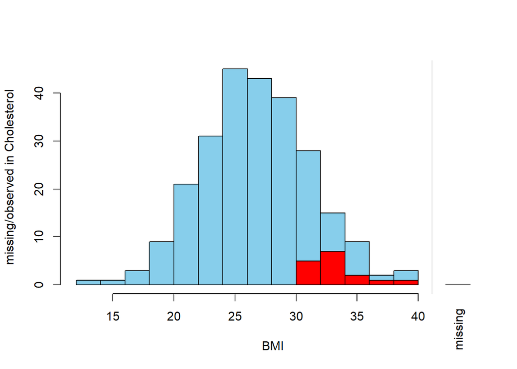

```r
histMiss(select(cholesterol, "BMI","Cholesterol"))
```

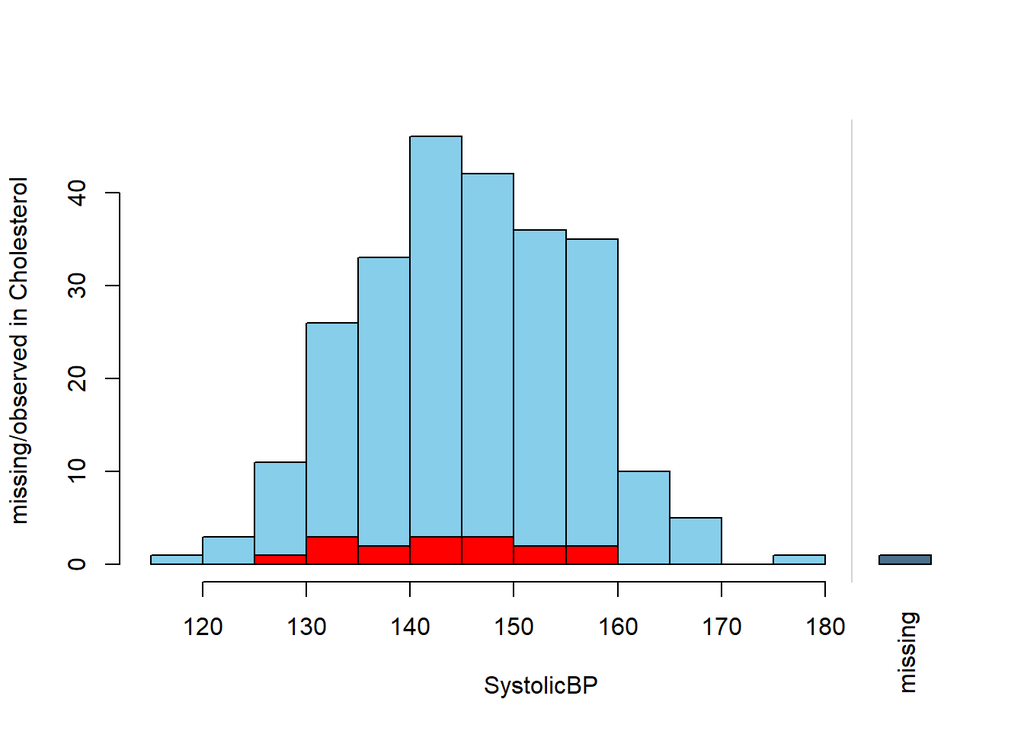

```r
histMiss(select(cholesterol, "SystolicBP","Cholesterol"))
```

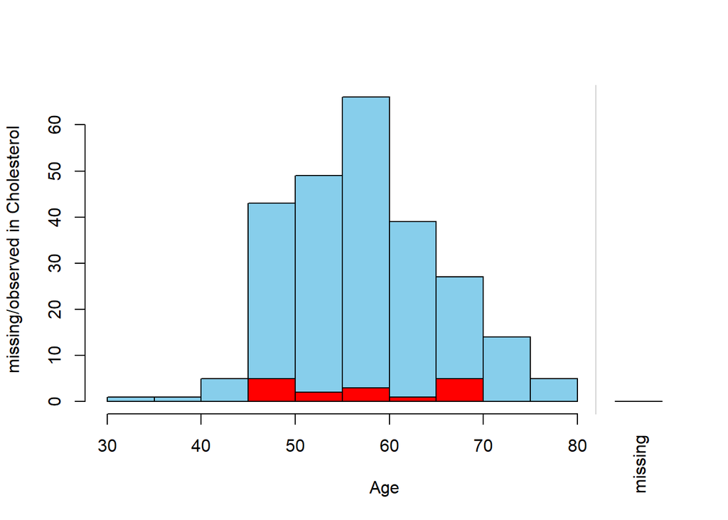

```r
histMiss(select(cholesterol, "Age","Cholesterol"))
```

There appears to be a missing data pattern for Cholesterol and BMI where data is more likely to be missing from Cholesterol when BMI is high.

Q8

1. The data missing from the census questionnaire is MAR since it is related to whether there are children in the household, if there are no children in the house hold then the data is missing. This missing data process is ignorable and no action is taken.
2. The data missing for the electoral poll questionnaire are MCAR since the participants are chosen at random. Provided the sample size is large enough, the data can be analysed using complete cases only.
3. The data missing for the concentration of pesticide is MNAR since the data is missing for the plants that received the highest concentration of pesticide. In this instance knowledge of the toxisity of the pesticide at high concentrations should be presented in the analysis.